# HW 6

Jan Netík

### 1

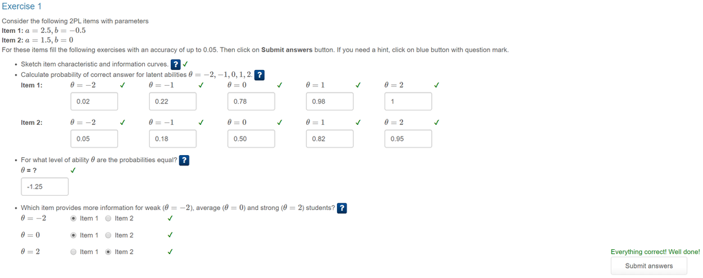

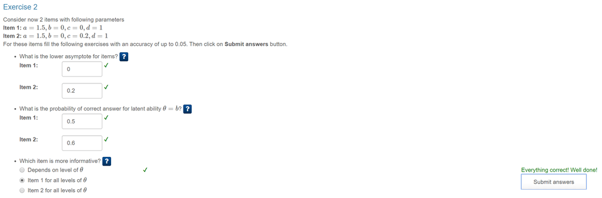

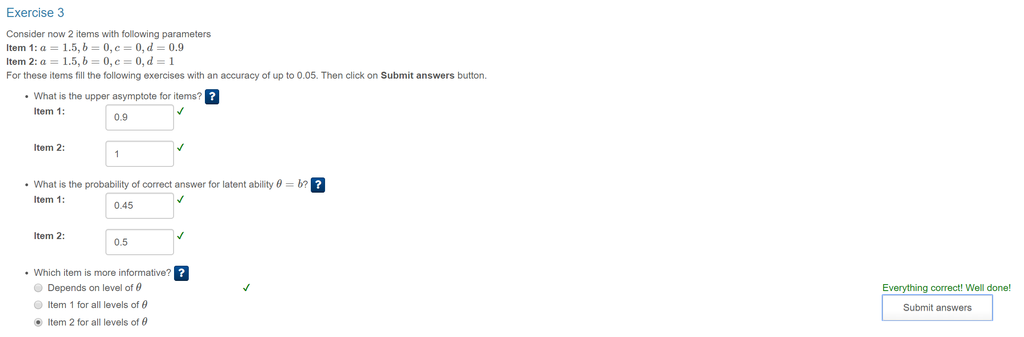

### 2.1.1 Rasch

$N_{obs} = 3037$  
$N_{E\ items} = 24$

### 2.1.2

V44,  
V5,  
$r_{factor-total\ scores} = 1$

### 2.1.3 1PL

In Rasch model, $a$ term is always fixed to 1, in 1PL model, $a$ is free to vary, but the value is the same for all items. In the fitted 1PL model, $a = 0.26$ for all items.

None of the items is the most informative, as the item information is just the first derivative of the item characteristic curve, which depends on $a$ parameter (and which value is the same of all items in both Rasch and 1PL models).

### 2.1.4 2PL

V5, V15, V20, V29, V32, V34, V37, V41, V51

The negative discrimination is caused by “negative wording” of those items.

The most informative item is V51.

$r_{factor-total\ scores} = 0.536$, as opposed to Rasch model, for which $r_{factor-total\ scores} = 1$

### 2.2.1

```r
data <- read_csv("epi_escore.csv")

reverse.items <- function(data, which.items) {
  rev.data <- sapply(data, function(x)
    as.numeric(x == 0))
  new.data <- data
  new.data[, which.items] <- rev.data[, which.items]
  return(new.data)
}

which.items <- paste0("V", c(5, 15, 20, 29, 32, 34, 37, 41, 51))

revdata <- reverse.items(data = data, which.items = which.items)
```

### 2.2.2

```r
fit2PL.mirt <- mirt(data = data, model = 1, itemtype = "2PL")
```

[output not shown]

```r
fit2PL.mirt.rev <- mirt(data = revdata, model = 1, itemtype = "2PL")
```

[output not shown]

### 2.2.3

```r
coef_tbl <- tibble(
original_a = coef(fit2PL.mirt, simplify = T)$items[,1],
reversed_a = coef(fit2PL.mirt.rev, simplify = T)$items[,1],
original_b = coef(fit2PL.mirt, simplify = T)$items[,2],
reversed_b = coef(fit2PL.mirt.rev, simplify = T)$items[,2]
)

rownames(coef_tbl) <- names(data)

coef_tbl %>% pander(digits = 2)
```

|  | original_a | reversed_a | original_b | reversed_b |
| --- | --- | --- | --- | --- |
| **V1** | 0.22 | 0.22 | -0.96 | -0.96 |
| **V3** | 0.87 | 0.87 | -0.24 | -0.24 |
| **V5** | -0.41 | 0.41 | -1.6 | 1.6 |
| **V8** | 0.37 | 0.37 | 0.69 | 0.69 |
| **V10** | 0.77 | 0.77 | 2.3 | 2.3 |
| **V13** | 0.97 | 0.97 | -0.21 | -0.21 |
| **V15** | -1.3 | 1.3 | 2 | -2 |
| **V17** | 1.6 | 1.6 | -1.9 | -1.9 |
| **V20** | -0.79 | 0.79 | -1.4 | 1.4 |
| **V22** | 0.41 | 0.41 | -0.27 | -0.27 |
| **V25** | 2.4 | 2.4 | -1.7 | -1.7 |
| **V27** | 1.8 | 1.8 | -0.92 | -0.92 |
| **V29** | -1.6 | 1.6 | 1.1 | -1.1 |
| **V32** | -0.74 | 0.74 | 1.2 | -1.2 |
| **V34** | -0.12 | 0.12 | -0.43 | 0.43 |
| **V37** | -0.53 | 0.53 | 0.52 | -0.52 |
| **V39** | 0.78 | 0.78 | -0.24 | -0.24 |
| **V41** | -0.25 | 0.25 | 1 | -1 |
| **V44** | 1 | 1 | 2.6 | 2.6 |
| **V46** | 0.72 | 0.72 | 0.12 | 0.12 |
| **V49** | 0.97 | 0.97 | -1.8 | -1.8 |
| **V51** | -2.4 | 2.4 | 2.3 | -2.3 |
| **V53** | 1.7 | 1.7 | 0.53 | 0.53 |
| **V56** | 0.55 | 0.55 | 0.33 | 0.33 |

```r
a_diff <- sum(abs(coef_tbl$original_a) - abs(coef_tbl$reversed_a))
b_diff <- sum(abs(coef_tbl$original_b) - abs(coef_tbl$reversed_b))
```

Parameters of “negative-worded” items in model based on original data are additive inverse of parameters of model based on rescored data. Thus, sum of differences in absolute values of parameters $\mathit{diff_a} = 0.0011466$; for $b$ parameters, $\mathit{diff_b} = 7.1219128\times 10^{-4}$. Ideally, those values should be zero. This does not apply probably due to some “fitting artefacts”.

### 2.2.4

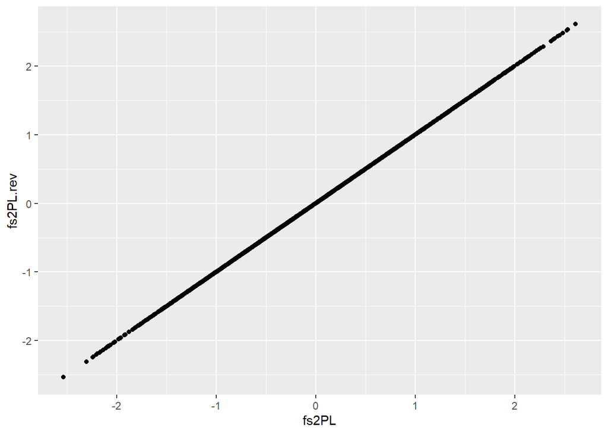

```r
fs2PL <- as.vector(fscores(fit2PL.mirt))
fs2PL.rev <- as.vector(fscores(fit2PL.mirt.rev))

qplot(fs2PL, fs2PL.rev)
```

```r
cor.test(fs2PL, fs2PL.rev)
```

```
##
##  Pearson's product-moment correlation
##
## data:  fs2PL and fs2PL.rev
## t = 1024076, df = 3035, p-value < 2.2e-16
## alternative hypothesis: true correlation is not equal to 0
## 95 percent confidence interval:
##  1 1
## sample estimates:
## cor
##   1
```

$r_{original-reversed\ fscore} = 1$  
I assume that estimated thetas are the same for both models because model were calibrated to account for and handle these “negative-worded” items.

### 4

It may be convenient to introduce so-called “jitter” in `ShinyItemAnalysis` plots.

Excerpt from `ggplot2` documentation:

> It adds a small amount of random variation to the location of each point, and is a useful way of handling overplotting caused by discreteness in smaller datasets.

Example here ;-)

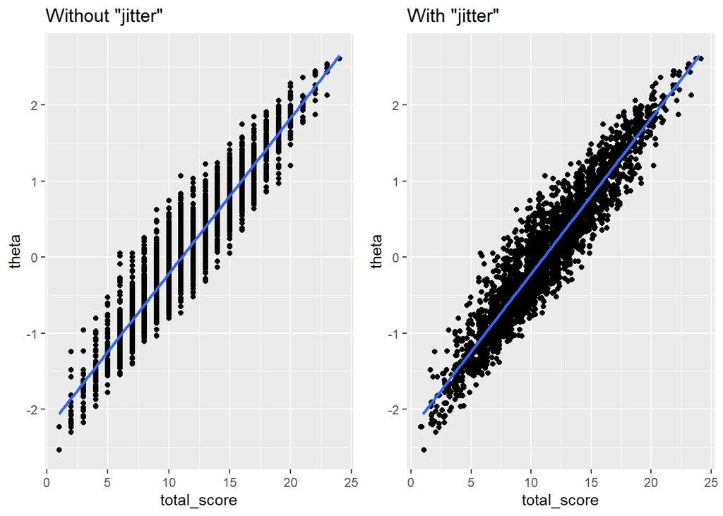

```r
without_jitter <- tibble(theta = fscores(fit2PL.mirt.rev),
       total_score = rowSums(revdata)) %>%
  ggplot(aes(total_score, theta)) +
  geom_point() +
  geom_smooth(method = "lm") +
  labs(title = 'Without "jitter"')

with_jitter <- tibble(theta = fscores(fit2PL.mirt.rev),
       total_score = rowSums(revdata)) %>%
  ggplot(aes(total_score, theta)) +
  geom_point(position = "jitter") + # NOTE
  geom_smooth(method = "lm") +
  labs(title = 'With "jitter"')

grid.arrange(without_jitter, with_jitter, ncol = 2)
```